# Praca domowa 3

Ada Wojterska

## Źródła

Przedstawiony wykres pochodzi ze strony internetowej https://www.investing.com/analysis/memory-inflation-warps-bond-yields-200653326, został opublikowany 23.10.2024 r.

## Wykres przed zmianą

[figure not shown]

wykres przed zmiana

## Elementy wymagające poprawy

Przedstawiony wykres zawiera wiele błędów. Przede wszytskim jest to bardzo nieczytelna oś X, która jest dostosowana jedynie do jednego z przedziałów czasowych ukazanych na wykresie. Możemy się jedynie domyślać, że rok 1966 odpowiada 2020, a każdy kolejny następnemu (np. 1967 to 2021). Także oś Y, ozaczająca procentowy poziom inflacji rok do roku, nie została opisana. Tytuł wykresu może także okazać się mylący, bowiem nie są na nim przedstawione lata 70., a pewien okres wykraczający poza nie. Oczywiście możemy też polemizować z słusznością porównywania właśnie tak wybranych okresów, jednak wykres ten jest odpowiedzią - poprawką do innego wykresu (Chyba zrobionego jeszcze gorzej, ale niestety starszego:)), więc postanowiłam zachować wybrane przez autorów przedziały czasu, jako że celem było właśnie podważenie słuszności porównywania ich.

## Wykres po zmianie

Komentarz: Przy tworzeniu wykresu wykorzytsałam dane na temat inflacji w USA ze strony https://data.bls.gov/timeseries/CUUR0000SA0?years_option=all_years&fbclid=IwZXh0bgNhZW0CMTEAAR3_jYIvXDJsOcSezt0XJYfAvcSnu-eseuy4VB9coA00fnipQ99TH4kybLk_aem_mQm3Snmg2X_F3qsufDUGwg, ponieważ nie znalzłam niestety w artykule źródła danych, z których konkretnie korzystał autor artykułu. Inflacja została przeskalowana, ponieważ w dostępnym źródle była ona obliczana względem roku 1982.

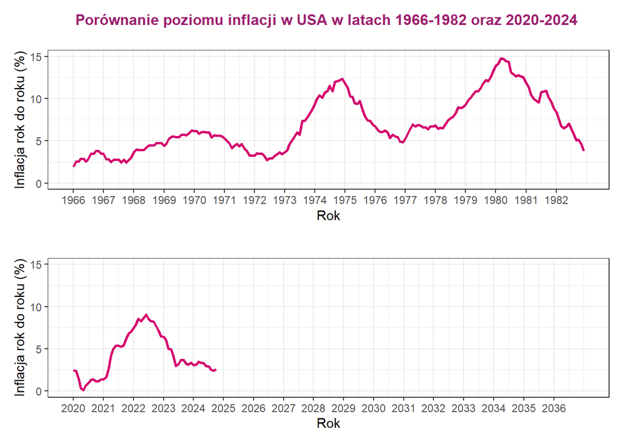

```r
df2_l <- df2 %>%
  pivot_longer(
    cols = -Year,
    names_to = "Month",
    values_to = "Inflation"
  )

month_map <- c(
  "Jan" = 1, "Feb" = 2, "Mar" = 3, "Apr" = 4, "May" = 5,
  "Jun" = 6, "Jul" = 7, "Aug" = 8, "Sep" = 9,
  "Oct" = 10, "Nov" = 11, "Dec" = 12
)

# Zamiana nazw miesięcy na liczby
df2_l$MonthNum <- month_map[df2_l$Month]

# Utworzenie daty
df2_l$Date <- as.Date(paste(df2_l$Year, df2_l$MonthNum, "1", sep = "-"), format = "%Y-%m-%d")

#Policzenie inflacji YoY
df2_l <- df2_l %>%
  group_by(MonthNum) %>%
  arrange(Year) %>%
  mutate(Inflation_YOY = (Inflation - lag(Inflation)) / lag(Inflation) * 100) %>%
  ungroup()

# Usuwanie wartości NA, które mogą pojawić się w wyniku opóźnienia (lag) w pierwszym roku
df2_l <- df2_l %>% filter(!is.na(Inflation_YOY))

#inflacja lata 70

df2_l_70s <- df2_l %>%
  filter(format(Date, "%Y") >= "1966" & format(Date, "%Y") < "1983")

plot_70s <- ggplot(df2_l_70s, aes(x = Date, y = Inflation_YOY)) +
  geom_line(color = "#D5006D", linewidth = 1) +
  labs(
    title = "Porównanie poziomu inflacji w USA w latach 1966-1982 oraz 2020-2024 \n",
    x = "Rok",
    y = "Inflacja rok do roku (%)"
  ) +
  theme_minimal() +
  scale_x_date(
    breaks = seq(from = min(df2_l_70s$Date), to = max(df2_l_70s$Date), by = "1 year"),
    date_labels = "%Y"
  ) +
  scale_y_continuous(
    limits = c(0, 15)
  ) +
  theme(axis.text.x = element_text(angle = 45, hjust = 1)) +# Obrót etykiet na osi X
  theme_bw() +
  theme(
    plot.title = element_text(size = 12, face = "bold", color = "#9C1E6D", hjust = 0.5),  # Wyśrodkowanie i       kolor tytułu
  )

# inflacja nowa

df2_l_20s <- df2_l %>%
  filter(format(Date, "%Y") >= "2020" & format(Date, "%Y") <= "2024")

plot_20s <- ggplot(df2_l_20s, aes(x = Date, y = Inflation_YOY)) +
  geom_line(color = "#D5006D", linewidth = 1) +
  labs(
    title = "",
    x = "Rok",
    y = "Inflacja rok do roku (%)"
  ) +
  theme_minimal() +
  scale_x_date(
    breaks = seq(from = min(df2_l_20s$Date), to = as.Date("2036-12-31"), by = "1 year"),
    date_labels = "%Y"
  ) +
  scale_y_continuous(
    limits = c(0, 15)
  ) +
  expand_limits(x = as.Date("2036-12-31")) +  # Rozciągnięcie osi X do 2030 roku
  theme(axis.text.x = element_text(angle = 45, hjust = 1)) +
  theme_bw()


# łączenie wykresów

plot_70s / plot_20s + plot_layout(ncol = 1, heights = c(1, 1))
```

## Komentarz po zmianie

Tak jak wspomniałam wcześniej, postanowiłam zachować cel wykresu założony przez autorów, czyli porównanie zmian inflacji w dwóch przedziałach czasu. Z tego powodu nie stworzyłam np. jednego wykresu z danymi o inflacji w latach 1966-2024. Rozłożyłam dane na dwa wykresy, aby rok z osi X był łatwiejszy do odczytania, jednocześnie wykorzytsując jednakowe skale na osi Y, aby dane były łatwe do porównania. Doprecyzowałam także tytuł wykresu oraz dodałam tytuł osi Y.